# Project 1: Wrangling, Exploration, Visualization

SDS322E

## Data Wrangling, Exploration, Visualization

### Tia Frederick. EID: tmf977

####My two datasets are USArrests: Violent Crime Rates by US State and Anscombe: U.S. State Public-School Expenditures. US Arressts contains statistics in arrests per 100,000 residents for assault, murder, and rape in each of the 50 U.S. states in 1973, and the variables are labeled as ‘Assault’, ‘Murder’, and ‘Rape’, respectively. The dataset also provides the percent of the population living in urban areas, labeled as ‘UrbanPop’. The Anscombe dataset contains statistics for the U.S. states plus Washington D.C. in 1970 for per-capita education expenditures in dollars (‘education’ variable), per-capita income (‘income’ variable), proportion under 18 years old per 1000 residents (‘young’ variable), and urban proportion per 1000 (‘urban’ variable). The USArrest dataset has 50 observations and 5 variables, and the Anscombe dataset has 51 observations and 5 variables, and the variable name for the states column is called “X1” for both datasets. I am interested in anaylzing these two datasets to see if there is any correlation between the crime arrests and income in each state. My hypothesis is that the states with the lower per-capita income has the most crime arrests, and the higher per-capita income has the least crime arrests. Therefore, I would expect a negative correlation between these two variables. I would also predict this would be the same for the relationship between crime arrests and education expenditures.

```r
# read your datasets in here, e.g., with read_csv()
library(tidyverse)

# The USArrests dataset will be labeled as data1 The
# USArrests dataset will be labeled as data2
data1 <- read_csv("https://vincentarelbundock.github.io/Rdatasets/csv/carData/Anscombe.csv")
data2 <- read_csv("https://vincentarelbundock.github.io/Rdatasets/csv/datasets/USArrests.csv")
```

#### Tidying: Reshaping

```r
# your tidying code (if applicable; can also wait until
# wrangling section)

# Recall: when your data is tidy, the values of each variable
# fall in their own column vector.

# data1 and data2 are already tidy; therefore, I will untidy
# and then retidy to demonstrate how to reshape data with
# pivot_wider() and pivot_longer()

# The original datasets:
data1
```

```
## # A tibble: 51 x 5
##    X1    education income young urban
##    <chr>     <dbl>  <dbl> <dbl> <dbl>
##  1 ME          189   2824  351.   508
##  2 NH          169   3259  346.   564
##  3 VT          230   3072  348.   322
##  4 MA          168   3835  335.   846
##  5 RI          180   3549  327.   871
##  6 CT          193   4256  341    774
##  7 NY          261   4151  326.   856
##  8 NJ          214   3954  334.   889
##  9 PA          201   3419  326.   715
## 10 OH          172   3509  354.   753
## # … with 41 more rows
```

```r
data2
```

```
## # A tibble: 50 x 5
##    X1          Murder Assault UrbanPop  Rape
##    <chr>        <dbl>   <dbl>    <dbl> <dbl>
##  1 Alabama       13.2     236       58  21.2
##  2 Alaska        10       263       48  44.5
##  3 Arizona        8.1     294       80  31
##  4 Arkansas       8.8     190       50  19.5
##  5 California     9       276       91  40.6
##  6 Colorado       7.9     204       78  38.7
##  7 Connecticut    3.3     110       77  11.1
##  8 Delaware       5.9     238       72  15.8
##  9 Florida       15.4     335       80  31.9
## 10 Georgia       17.4     211       60  25.8
## # … with 40 more rows
```

```r
# Untidy:
data1 <- data1 %>% pivot_wider(names_from = X1, values_from = urban)
data2 <- data2 %>% pivot_wider(names_from = X1, values_from = UrbanPop)
data1
```

```
## # A tibble: 51 x 54
##    education income young    ME    NH    VT    MA    RI    CT    NY    NJ    PA
##        <dbl>  <dbl> <dbl> <dbl> <dbl> <dbl> <dbl> <dbl> <dbl> <dbl> <dbl> <dbl>
##  1       189   2824  351.   508    NA    NA    NA    NA    NA    NA    NA    NA
##  2       169   3259  346.    NA   564    NA    NA    NA    NA    NA    NA    NA
##  3       230   3072  348.    NA    NA   322    NA    NA    NA    NA    NA    NA
##  4       168   3835  335.    NA    NA    NA   846    NA    NA    NA    NA    NA
##  5       180   3549  327.    NA    NA    NA    NA   871    NA    NA    NA    NA
##  6       193   4256  341     NA    NA    NA    NA    NA   774    NA    NA    NA
##  7       261   4151  326.    NA    NA    NA    NA    NA    NA   856    NA    NA
##  8       214   3954  334.    NA    NA    NA    NA    NA    NA    NA   889    NA
##  9       201   3419  326.    NA    NA    NA    NA    NA    NA    NA    NA   715
## 10       172   3509  354.    NA    NA    NA    NA    NA    NA    NA    NA    NA
## # … with 41 more rows, and 42 more variables: OH <dbl>, IN <dbl>, IL <dbl>,
## #   MI <dbl>, WI <dbl>, MN <dbl>, IO <dbl>, MO <dbl>, ND <dbl>, SD <dbl>,
## #   NE <dbl>, KA <dbl>, DE <dbl>, MD <dbl>, DC <dbl>, VA <dbl>, WV <dbl>,
## #   NC <dbl>, SC <dbl>, GA <dbl>, FL <dbl>, KY <dbl>, TN <dbl>, AL <dbl>,
## #   MS <dbl>, AR <dbl>, LA <dbl>, OK <dbl>, TX <dbl>, MT <dbl>, ID <dbl>,
## #   WY <dbl>, CO <dbl>, NM <dbl>, AZ <dbl>, UT <dbl>, NV <dbl>, WA <dbl>,
## #   OR <dbl>, CA <dbl>, AK <dbl>, HI <dbl>
```

```r
data2
```

```
## # A tibble: 50 x 53
##    Murder Assault  Rape Alabama Alaska Arizona Arkansas California Colorado
##     <dbl>   <dbl> <dbl>   <dbl>  <dbl>   <dbl>    <dbl>      <dbl>    <dbl>
##  1   13.2     236  21.2      58     NA      NA       NA         NA       NA
##  2   10       263  44.5      NA     48      NA       NA         NA       NA
##  3    8.1     294  31        NA     NA      80       NA         NA       NA
##  4    8.8     190  19.5      NA     NA      NA       50         NA       NA
##  5    9       276  40.6      NA     NA      NA       NA         91       NA
##  6    7.9     204  38.7      NA     NA      NA       NA         NA       78
##  7    3.3     110  11.1      NA     NA      NA       NA         NA       NA
##  8    5.9     238  15.8      NA     NA      NA       NA         NA       NA
##  9   15.4     335  31.9      NA     NA      NA       NA         NA       NA
## 10   17.4     211  25.8      NA     NA      NA       NA         NA       NA
## # … with 40 more rows, and 44 more variables: Connecticut <dbl>,
## #   Delaware <dbl>, Florida <dbl>, Georgia <dbl>, Hawaii <dbl>, Idaho <dbl>,
## #   Illinois <dbl>, Indiana <dbl>, Iowa <dbl>, Kansas <dbl>, Kentucky <dbl>,
## #   Louisiana <dbl>, Maine <dbl>, Maryland <dbl>, Massachusetts <dbl>,
## #   Michigan <dbl>, Minnesota <dbl>, Mississippi <dbl>, Missouri <dbl>,
## #   Montana <dbl>, Nebraska <dbl>, Nevada <dbl>, `New Hampshire` <dbl>, `New
## #   Jersey` <dbl>, `New Mexico` <dbl>, `New York` <dbl>, `North
## #   Carolina` <dbl>, `North Dakota` <dbl>, Ohio <dbl>, Oklahoma <dbl>,
## #   Oregon <dbl>, Pennsylvania <dbl>, `Rhode Island` <dbl>, `South
## #   Carolina` <dbl>, `South Dakota` <dbl>, Tennessee <dbl>, Texas <dbl>,
## #   Utah <dbl>, Vermont <dbl>, Virginia <dbl>, Washington <dbl>, `West
## #   Virginia` <dbl>, Wisconsin <dbl>, Wyoming <dbl>
```

```r
# The datasets are now untidy. Let's demonstrate how to
# retidy with pivot_longer()

data1 <- data1 %>% pivot_longer(cols = ME:HI, names_to = "X1",
    values_to = "urban", values_drop_na = TRUE)
data2 <- data2 %>% pivot_longer(cols = Alabama:Wyoming, names_to = "X1",
    values_to = "UrbanPop", values_drop_na = TRUE)
data1
```

```
## # A tibble: 51 x 5
##    education income young X1    urban
##        <dbl>  <dbl> <dbl> <chr> <dbl>
##  1       189   2824  351. ME      508
##  2       169   3259  346. NH      564
##  3       230   3072  348. VT      322
##  4       168   3835  335. MA      846
##  5       180   3549  327. RI      871
##  6       193   4256  341  CT      774
##  7       261   4151  326. NY      856
##  8       214   3954  334. NJ      889
##  9       201   3419  326. PA      715
## 10       172   3509  354. OH      753
## # … with 41 more rows
```

```r
data2
```

```
## # A tibble: 50 x 5
##    Murder Assault  Rape X1          UrbanPop
##     <dbl>   <dbl> <dbl> <chr>          <dbl>
##  1   13.2     236  21.2 Alabama           58
##  2   10       263  44.5 Alaska            48
##  3    8.1     294  31   Arizona           80
##  4    8.8     190  19.5 Arkansas          50
##  5    9       276  40.6 California        91
##  6    7.9     204  38.7 Colorado          78
##  7    3.3     110  11.1 Connecticut       77
##  8    5.9     238  15.8 Delaware          72
##  9   15.4     335  31.9 Florida           80
## 10   17.4     211  25.8 Georgia           60
## # … with 40 more rows
```

```r
# Let's move the column with the state names back to the
# front with the relocate() function:

data1 <- data1 %>% relocate(X1, .before = education)
data2 <- data2 %>% relocate(X1, .before = Murder)
data1
```

```
## # A tibble: 51 x 5
##    X1    education income young urban
##    <chr>     <dbl>  <dbl> <dbl> <dbl>
##  1 ME          189   2824  351.   508
##  2 NH          169   3259  346.   564
##  3 VT          230   3072  348.   322
##  4 MA          168   3835  335.   846
##  5 RI          180   3549  327.   871
##  6 CT          193   4256  341    774
##  7 NY          261   4151  326.   856
##  8 NJ          214   3954  334.   889
##  9 PA          201   3419  326.   715
## 10 OH          172   3509  354.   753
## # … with 41 more rows
```

```r
data2
```

```
## # A tibble: 50 x 5
##    X1          Murder Assault  Rape UrbanPop
##    <chr>        <dbl>   <dbl> <dbl>    <dbl>
##  1 Alabama       13.2     236  21.2       58
##  2 Alaska        10       263  44.5       48
##  3 Arizona        8.1     294  31         80
##  4 Arkansas       8.8     190  19.5       50
##  5 California     9       276  40.6       91
##  6 Colorado       7.9     204  38.7       78
##  7 Connecticut    3.3     110  11.1       77
##  8 Delaware       5.9     238  15.8       72
##  9 Florida       15.4     335  31.9       80
## 10 Georgia       17.4     211  25.8       60
## # … with 40 more rows
```

```r
# In data2, 'UrbanPop' is now the last column. The original
# data2 had 'UrbanPop' as the second to last column and
# 'Rape' as the last column. However, the re-tidied dataset
# looks better with 'UrbanPop' as the last column because now
# the crime columns ('Murder', 'Assault', and 'Rape') are
# grouped together.
```

#### Joining/Merging

```r
# data1 contains data for Washington D.C. and data2 does not.
# Therefore, I am dropping the 24th row in data1 which
# contains the data for D.C.
data1 <- data1[!(row.names(data1) %in% "24"), ]

# Arrange in alphabetical order
data1 <- data1 %>% arrange(data1)

# Changing the abbreviated state names of data1 to the full
# names of the states so that it would match data2.
data1[1, 1] <- "Alaska"
data1[2, 1] <- "Alabama"
data1[3, 1] <- "Arkansas"
data1[4, 1] <- "Arizona"
data1[5, 1] <- "California"
data1[6, 1] <- "Colorado"
data1[7, 1] <- "Connecticut"
data1[8, 1] <- "Delaware"
data1[9, 1] <- "Florida"
data1[10, 1] <- "Georgia"
data1[11, 1] <- "Hawaii"
data1[12, 1] <- "Idaho"
data1[13, 1] <- "Illinois"
data1[14, 1] <- "Indiana"
data1[15, 1] <- "Iowa"
data1[16, 1] <- "Kansas"
data1[17, 1] <- "Kentucky"
data1[18, 1] <- "Louisiana"
data1[19, 1] <- "Massachusetts"
data1[20, 1] <- "Maryland"
data1[21, 1] <- "Maine"
data1[22, 1] <- "Michigan"
data1[23, 1] <- "Minnesota"
data1[24, 1] <- "Missouri"
data1[25, 1] <- "Mississippi"
data1[26, 1] <- "Montana"
data1[27, 1] <- "North Carolina"
data1[28, 1] <- "North Dakota"
data1[29, 1] <- "Nebraska"
data1[30, 1] <- "New Hampshire"
data1[31, 1] <- "New Jersey"
data1[32, 1] <- "New Mexico"
data1[33, 1] <- "Nevada"
data1[34, 1] <- "New York"
data1[35, 1] <- "Ohio"
data1[36, 1] <- "Oklahoma"
data1[37, 1] <- "Oregon"
data1[38, 1] <- "Pennsylvania"
data1[39, 1] <- "Rhode Island"
data1[40, 1] <- "South Carolina"
data1[41, 1] <- "South Dakota"
data1[42, 1] <- "Tennessee"
data1[43, 1] <- "Texas"
data1[44, 1] <- "Utah"
data1[45, 1] <- "Virginia"
data1[46, 1] <- "Vermont"
data1[47, 1] <- "Washington"
data1[48, 1] <- "Wisconsin"
data1[49, 1] <- "West Virginia"
data1[50, 1] <- "Wyoming"

# Renaming the 'X1' column to 'States' in both datasets.
data1 <- rename(data1, States = X1)
data2 <- rename(data2, States = X1)

# Rename 'UrbanPop' column to 'UrbanPercent' for more
# clarification and distinction from the 'urban' column in
# data1.
data2 <- rename(data2, UrbanPercent = UrbanPop)

# Arrange in alphabetical order again.
data1 <- data1 %>% arrange(data1)

# Joining the two datasets
data3 <- full_join(data1, data2)
data3
```

```
## # A tibble: 50 x 9
##    States      education income young urban Murder Assault  Rape UrbanPercent
##    <chr>           <dbl>  <dbl> <dbl> <dbl>  <dbl>   <dbl> <dbl>        <dbl>
##  1 Alabama           112   2337  362.   584   13.2     236  21.2           58
##  2 Alaska            372   4146  440.   484   10       263  44.5           48
##  3 Arizona           207   3027  388.   796    8.1     294  31             80
##  4 Arkansas          134   2322  352.   500    8.8     190  19.5           50
##  5 California        273   3968  348.   909    9       276  40.6           91
##  6 Colorado          192   3340  358.   785    7.9     204  38.7           78
##  7 Connecticut       193   4256  341    774    3.3     110  11.1           77
##  8 Delaware          248   3795  376.   722    5.9     238  15.8           72
##  9 Florida           191   3191  336    805   15.4     335  31.9           80
## 10 Georgia           156   2781  371.   603   17.4     211  25.8           60
## # … with 40 more rows
```

```r
# 50 observations/rows in data1
nrow(data1)
```

```
## [1] 50
```

```r
# 50 observations/rows in each data2
nrow(data2)
```

```
## [1] 50
```

```r
# 50 observations/rows in each data3
nrow(data3)
```

```
## [1] 50
```

```r
# 5 variables/columns in each data1
ncol(data1)
```

```
## [1] 5
```

```r
# 5 variables/columns in each data2
ncol(data2)
```

```
## [1] 5
```

```r
# 9 variables/columns in each data1
ncol(data3)
```

```
## [1] 9
```

```r
# The Unique ID's in each dataset
colnames(data1)
```

```
## [1] "States"    "education" "income"    "young"     "urban"
```

```r
colnames(data2)
```

```
## [1] "States"       "Murder"       "Assault"      "Rape"         "UrbanPercent"
```

```r
colnames(data3)
```

```
## [1] "States"       "education"    "income"       "young"        "urban"
## [6] "Murder"       "Assault"      "Rape"         "UrbanPercent"
```

First off, I took out Washington D.C. from ‘data1’ so I could focus only on the 50 states and to merge it with ‘data2’. ‘data1’ also had the state names abbreviated, so I wrote out the full name for each so it would match with ‘data2’, and then I arranged it in alphabetical order. I also renamed the ‘X1’ column to ‘States’ and ‘UrbanPop’ to ‘UrbanPercent’ so it would be easier to understand the data. I then used full_join() so each state will have the statistics for ‘education’, ‘income’, ‘young’, ‘urban’, ‘Murder’, ‘Assault’, ‘Rape’, and ‘UrbanPercent’. No rows were dropped in the joined dataset. I named the joined dataset as ‘data3’ and it has 50 observations/rows and 9 variables/columns. ‘data1’ has 50 observations/rows and 5 variables/columns and ‘data2’ has 50 observations/rows and 5 variables/columns. The ID’s in ‘data1’ are “States”, “education”, “income”, “young”, “urban”. The ID’s in ‘data2’ are “States”, “Murder” “Assault”, “Rape”, “UrbanPercent”. The ID’s in ‘data3’ are “States”, “Murder”, “Assault”, “Rape”, “UrbanPercent”, “education”, “income”, “young”, “urban”. The variables “education”, “income”, “young”, “urban” appear in ‘data1’ and ‘data3’ but not in ‘data2’. The variables “Murder”, “Assault”, “Rape”, “UrbanPercent” appear in ‘data2’ and ‘data3’ but not ‘data1’. The variable “States” is the only one that is shared between all three datasets. Since ‘data1’ and ‘data2’ only had one variable in common, the joined dataset ‘data3’ has 9 columns. The dimensions of ‘data3’ is 50 by 9.

#### Wrangling

```r
# Use all six core `dplyr` functions in the service of
# generating summary tables/statistics filter(), mutate(),
# arrange(), select(), summarize(), group_by()

# Used mutate() to generate a variable called 'Total_Arrests'
# by adding up the data in the crime columns
data3 <- data3 %>% mutate(Total_Arrests = select(., Murder, Assault,
    Rape) %>% rowSums(na.rm = TRUE))

# Used mutate() to generate a variable called 'ratio' that is
# the ratio of total arrests to income in each state.
data3 %>% mutate(ratio = Total_Arrests/income)
```

```
## # A tibble: 50 x 11
##    States education income young urban Murder Assault  Rape UrbanPercent
##    <chr>      <dbl>  <dbl> <dbl> <dbl>  <dbl>   <dbl> <dbl>        <dbl>
##  1 Alaba…       112   2337  362.   584   13.2     236  21.2           58
##  2 Alaska       372   4146  440.   484   10       263  44.5           48
##  3 Arizo…       207   3027  388.   796    8.1     294  31             80
##  4 Arkan…       134   2322  352.   500    8.8     190  19.5           50
##  5 Calif…       273   3968  348.   909    9       276  40.6           91
##  6 Color…       192   3340  358.   785    7.9     204  38.7           78
##  7 Conne…       193   4256  341    774    3.3     110  11.1           77
##  8 Delaw…       248   3795  376.   722    5.9     238  15.8           72
##  9 Flori…       191   3191  336    805   15.4     335  31.9           80
## 10 Georg…       156   2781  371.   603   17.4     211  25.8           60
## # … with 40 more rows, and 2 more variables: Total_Arrests <dbl>, ratio <dbl>
```

```r
# Used filter() to see which states as an urban population
# greater than 60%
data3 %>% filter(UrbanPercent > 60)
```

```
## # A tibble: 31 x 10
##    States education income young urban Murder Assault  Rape UrbanPercent
##    <chr>      <dbl>  <dbl> <dbl> <dbl>  <dbl>   <dbl> <dbl>        <dbl>
##  1 Arizo…       207   3027  388.   796    8.1     294  31             80
##  2 Calif…       273   3968  348.   909    9       276  40.6           91
##  3 Color…       192   3340  358.   785    7.9     204  38.7           78
##  4 Conne…       193   4256  341    774    3.3     110  11.1           77
##  5 Delaw…       248   3795  376.   722    5.9     238  15.8           72
##  6 Flori…       191   3191  336    805   15.4     335  31.9           80
##  7 Hawaii       212   3513  383.   831    5.3      46  20.2           83
##  8 Illin…       189   3981  349.   830   10.4     249  24             83
##  9 India…       194   3412  359.   649    7.2     113  21             65
## 10 Kansas       196   3303  340.   661    6       115  18             66
## # … with 21 more rows, and 1 more variable: Total_Arrests <dbl>
```

```r
# Used a `stringr` function str_detect() to extract the data
# for Texas.
data3 %>% filter(str_detect(States, "Texas"))
```

```
## # A tibble: 1 x 10
##   States education income young urban Murder Assault  Rape UrbanPercent
##   <chr>      <dbl>  <dbl> <dbl> <dbl>  <dbl>   <dbl> <dbl>        <dbl>
## 1 Texas        155   3029  369.   797   12.7     201  25.5           80
## # … with 1 more variable: Total_Arrests <dbl>
```

```r
# Selected the variables 'States' and 'income' with select()
# and arranged income in descending order with arrange() to
# view the states with the highest per capita income to the
# lowest.
data3 %>% select(States, income) %>% arrange(desc(income))
```

```
## # A tibble: 50 x 2
##    States        income
##    <chr>          <dbl>
##  1 Connecticut     4256
##  2 New York        4151
##  3 Alaska          4146
##  4 Illinois        3981
##  5 California      3968
##  6 Nevada          3957
##  7 New Jersey      3954
##  8 Massachusetts   3835
##  9 Delaware        3795
## 10 Maryland        3742
## # … with 40 more rows
```

```r
# Computed summary statistics for each of my variables using
# `summarize` alone and with `group_by`

# Created a categorical variable called
# 'high_low_UrbanPercent' by dichotomizing a numeric variable
# ('UrbanPercent'). A high urban percentage is greater than
# or equal to 60% and a low urban percentage is lower than
# 60%.
data3$high_low_UrbanPercent <- as.factor(ifelse(data3$UrbanPercent <
    60, "low", "high"))
data3
```

```
## # A tibble: 50 x 11
##    States education income young urban Murder Assault  Rape UrbanPercent
##    <chr>      <dbl>  <dbl> <dbl> <dbl>  <dbl>   <dbl> <dbl>        <dbl>
##  1 Alaba…       112   2337  362.   584   13.2     236  21.2           58
##  2 Alaska       372   4146  440.   484   10       263  44.5           48
##  3 Arizo…       207   3027  388.   796    8.1     294  31             80
##  4 Arkan…       134   2322  352.   500    8.8     190  19.5           50
##  5 Calif…       273   3968  348.   909    9       276  40.6           91
##  6 Color…       192   3340  358.   785    7.9     204  38.7           78
##  7 Conne…       193   4256  341    774    3.3     110  11.1           77
##  8 Delaw…       248   3795  376.   722    5.9     238  15.8           72
##  9 Flori…       191   3191  336    805   15.4     335  31.9           80
## 10 Georg…       156   2781  371.   603   17.4     211  25.8           60
## # … with 40 more rows, and 2 more variables: Total_Arrests <dbl>,
## #   high_low_UrbanPercent <fct>
```

```r
data3 %>% group_by(high_low_UrbanPercent) %>% summarize(max_income = max(income,
    na.rm = T))
```

```
## # A tibble: 2 x 2
##   high_low_UrbanPercent max_income
##   <fct>                      <dbl>
## 1 high                        4256
## 2 low                         4146
```

```r
data3 %>% group_by(high_low_UrbanPercent) %>% summarize(min_income = min(income,
    na.rm = T))
```

```
## # A tibble: 2 x 2
##   high_low_UrbanPercent min_income
##   <fct>                      <dbl>
## 1 high                        2634
## 2 low                         2081
```

```r
data3 %>% summarize(mean_income = mean(income, na.rm = T))
```

```
## # A tibble: 1 x 1
##   mean_income
##         <dbl>
## 1       3201.
```

```r
data3 %>% summarize(sd_income = sd(income, na.rm = T))
```

```
## # A tibble: 1 x 1
##   sd_income
##       <dbl>
## 1      539.
```

```r
data3 %>% summarize(median_income = median(income, na.rm = T))
```

```
## # A tibble: 1 x 1
##   median_income
##           <dbl>
## 1          3248
```

```r
data3 %>% group_by(high_low_UrbanPercent) %>% summarize(max_education = max(education,
    na.rm = T))
```

```
## # A tibble: 2 x 2
##   high_low_UrbanPercent max_education
##   <fct>                         <dbl>
## 1 high                            273
## 2 low                             372
```

```r
data3 %>% group_by(high_low_UrbanPercent) %>% summarize(min_education = min(education,
    na.rm = T))
```

```
## # A tibble: 2 x 2
##   high_low_UrbanPercent min_education
##   <fct>                         <dbl>
## 1 high                            135
## 2 low                             112
```

```r
data3 %>% summarize(mean_education = mean(education, na.rm = T))
```

```
## # A tibble: 1 x 1
##   mean_education
##            <dbl>
## 1           195.
```

```r
data3 %>% summarize(sd_education = sd(education, na.rm = T))
```

```
## # A tibble: 1 x 1
##   sd_education
##          <dbl>
## 1         46.4
```

```r
data3 %>% summarize(median_education = median(education, na.rm = T))
```

```
## # A tibble: 1 x 1
##   median_education
##              <dbl>
## 1             192.
```

```r
data3 %>% group_by(high_low_UrbanPercent) %>% summarize(max_young = max(young,
    na.rm = T))
```

```
## # A tibble: 2 x 2
##   high_low_UrbanPercent max_young
##   <fct>                     <dbl>
## 1 high                       422.
## 2 low                        440.
```

```r
data3 %>% group_by(high_low_UrbanPercent) %>% summarize(min_young = min(young,
    na.rm = T))
```

```
## # A tibble: 2 x 2
##   high_low_UrbanPercent min_young
##   <fct>                     <dbl>
## 1 high                       326.
## 2 low                        329.
```

```r
data3 %>% summarize(mean_young = mean(young, na.rm = T))
```

```
## # A tibble: 1 x 1
##   mean_young
##        <dbl>
## 1       359.
```

```r
data3 %>% summarize(sd_young = sd(young, na.rm = T))
```

```
## # A tibble: 1 x 1
##   sd_young
##      <dbl>
## 1     24.2
```

```r
data3 %>% summarize(median_young = median(young, na.rm = T))
```

```
## # A tibble: 1 x 1
##   median_young
##          <dbl>
## 1         354.
```

```r
data3 %>% group_by(high_low_UrbanPercent) %>% summarize(max_urban = max(urban,
    na.rm = T))
```

```
## # A tibble: 2 x 2
##   high_low_UrbanPercent max_urban
##   <fct>                     <dbl>
## 1 high                        909
## 2 low                         588
```

```r
data3 %>% group_by(high_low_UrbanPercent) %>% summarize(min_urban = min(urban,
    na.rm = T))
```

```
## # A tibble: 2 x 2
##   high_low_UrbanPercent min_urban
##   <fct>                     <dbl>
## 1 high                        603
## 2 low                         322
```

```r
data3 %>% summarize(mean_urban = mean(urban, na.rm = T))
```

```
## # A tibble: 1 x 1
##   mean_urban
##        <dbl>
## 1       658.
```

```r
data3 %>% summarize(sd_urban = sd(urban, na.rm = T))
```

```
## # A tibble: 1 x 1
##   sd_urban
##      <dbl>
## 1     145.
```

```r
data3 %>% summarize(median_urban = median(urban, na.rm = T))
```

```
## # A tibble: 1 x 1
##   median_urban
##          <dbl>
## 1         662.
```

```r
data3 %>% group_by(high_low_UrbanPercent) %>% summarize(max_Murder = max(Murder,
    na.rm = T))
```

```
## # A tibble: 2 x 2
##   high_low_UrbanPercent max_Murder
##   <fct>                      <dbl>
## 1 high                        17.4
## 2 low                         16.1
```

```r
data3 %>% group_by(high_low_UrbanPercent) %>% summarize(min_Murder = min(Murder,
    na.rm = T))
```

```
## # A tibble: 2 x 2
##   high_low_UrbanPercent min_Murder
##   <fct>                      <dbl>
## 1 high                         2.6
## 2 low                          0.8
```

```r
data3 %>% summarize(mean_Murder = mean(Murder, na.rm = T))
```

```
## # A tibble: 1 x 1
##   mean_Murder
##         <dbl>
## 1        7.79
```

```r
data3 %>% summarize(sd_Murder = sd(Murder, na.rm = T))
```

```
## # A tibble: 1 x 1
##   sd_Murder
##       <dbl>
## 1      4.36
```

```r
data3 %>% summarize(median_Murder = median(Murder, na.rm = T))
```

```
## # A tibble: 1 x 1
##   median_Murder
##           <dbl>
## 1          7.25
```

```r
data3 %>% group_by(high_low_UrbanPercent) %>% summarize(max_Assault = max(Assault,
    na.rm = T))
```

```
## # A tibble: 2 x 2
##   high_low_UrbanPercent max_Assault
##   <fct>                       <dbl>
## 1 high                          335
## 2 low                           337
```

```r
data3 %>% group_by(high_low_UrbanPercent) %>% summarize(min_Assualt = min(Assault,
    na.rm = T))
```

```
## # A tibble: 2 x 2
##   high_low_UrbanPercent min_Assualt
##   <fct>                       <dbl>
## 1 high                           46
## 2 low                            45
```

```r
data3 %>% summarize(mean_Assault = mean(Assault, na.rm = T))
```

```
## # A tibble: 1 x 1
##   mean_Assault
##          <dbl>
## 1         171.
```

```r
data3 %>% summarize(sd_Assault = sd(Assault, na.rm = T))
```

```
## # A tibble: 1 x 1
##   sd_Assault
##        <dbl>
## 1       83.3
```

```r
data3 %>% summarize(median_Assault = median(Assault, na.rm = T))
```

```
## # A tibble: 1 x 1
##   median_Assault
##            <dbl>
## 1            159
```

```r
data3 %>% group_by(high_low_UrbanPercent) %>% summarize(max_UrbanPercent = max(UrbanPercent,
    na.rm = T))
```

```
## # A tibble: 2 x 2
##   high_low_UrbanPercent max_UrbanPercent
##   <fct>                            <dbl>
## 1 high                                91
## 2 low                                 59
```

```r
data3 %>% group_by(high_low_UrbanPercent) %>% summarize(min_UrbanPercent = min(UrbanPercent,
    na.rm = T))
```

```
## # A tibble: 2 x 2
##   high_low_UrbanPercent min_UrbanPercent
##   <fct>                            <dbl>
## 1 high                                60
## 2 low                                 32
```

```r
data3 %>% summarize(mean_UrbanPercent = mean(UrbanPercent, na.rm = T))
```

```
## # A tibble: 1 x 1
##   mean_UrbanPercent
##               <dbl>
## 1              65.5
```

```r
data3 %>% summarize(sd_UrbanPercent = sd(UrbanPercent, na.rm = T))
```

```
## # A tibble: 1 x 1
##   sd_UrbanPercent
##             <dbl>
## 1            14.5
```

```r
data3 %>% summarize(median_UrbanPercent = median(UrbanPercent,
    na.rm = T))
```

```
## # A tibble: 1 x 1
##   median_UrbanPercent
##                 <dbl>
## 1                  66
```

```r
data3 %>% group_by(high_low_UrbanPercent) %>% summarize(max_Rape = max(Rape,
    na.rm = T))
```

```
## # A tibble: 2 x 2
##   high_low_UrbanPercent max_Rape
##   <fct>                    <dbl>
## 1 high                      46
## 2 low                       44.5
```

```r
data3 %>% group_by(high_low_UrbanPercent) %>% summarize(min_Rape = min(Rape,
    na.rm = T))
```

```
## # A tibble: 2 x 2
##   high_low_UrbanPercent min_Rape
##   <fct>                    <dbl>
## 1 high                       8.3
## 2 low                        7.3
```

```r
data3 %>% summarize(mean_Rape = mean(Rape, na.rm = T))
```

```
## # A tibble: 1 x 1
##   mean_Rape
##       <dbl>
## 1      21.2
```

```r
data3 %>% summarize(sd_Rape = sd(Rape, na.rm = T))
```

```
## # A tibble: 1 x 1
##   sd_Rape
##     <dbl>
## 1    9.37
```

```r
data3 %>% summarize(median_Rape = median(Rape, na.rm = T))
```

```
## # A tibble: 1 x 1
##   median_Rape
##         <dbl>
## 1        20.1
```

```r
# Provided a table of counts for each level for my
# categorical variable.
data3 %>% group_by(high_low_UrbanPercent) %>% summarize(counts = n())
```

```
## # A tibble: 2 x 2
##   high_low_UrbanPercent counts
##   <fct>                  <int>
## 1 high                      33
## 2 low                       17
```

Firstly, I used mutate() to generate a variable called “Total_Arrests” by adding up the data in the crime columns and used mutate() again to generate a variable called “ratio” that is the ratio of total arrests to income in each state. I used filter() to see which states as an urban population greater than 60%. I also used a `stringr` function called str_detect() to extract the data for Texas, and found the urban percentage for Texas in 1973 was 80%. I then selected the variables ‘States’ and ‘income’ with select() and arranged income in descending order with arrange() to view the states with the highest per capita income to the lowest, which showed that Connecticut had the highest per-capita income at 4256 and Mississippi the lowest at 2081. Next, I computed summary statistics for each of my variables using `summarize` alone and with `group_by` and created a categorical variable called “high_low_UrbanPercent” by dichotomizing a numeric variable (“UrbanPercent”). A urban percentage is categorized as high if it is greater than or equal to 60% and a low urban percentage is lower than 60%. One of my interesting finding is that there were 33 states that were categorized has a high urban percentage and 17 states with a low urban percentage.

#### Visualizing

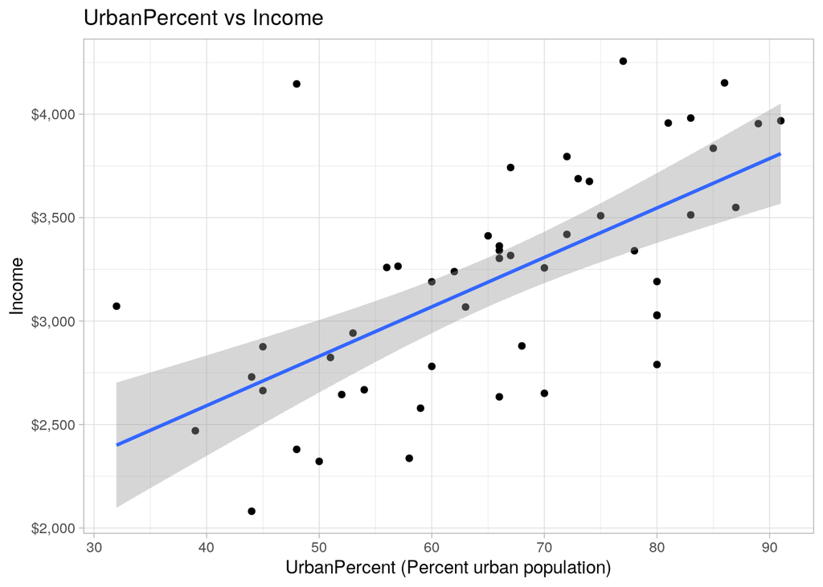

```r
ggplot(data = data3, aes(x = UrbanPercent, y = income)) + geom_point() +
    geom_smooth(method = "lm") + ggtitle("UrbanPercent vs Income") +
    xlab("UrbanPercent (Percent urban population)") + ylab("Income") +
    theme_light() + scale_y_continuous(labels = scales::dollar)
```

There is a positive relationship between the urban percentage and per-capita income. Therefore, this plot depicts that a state with a higher urban percentage has a higher per-capita income.

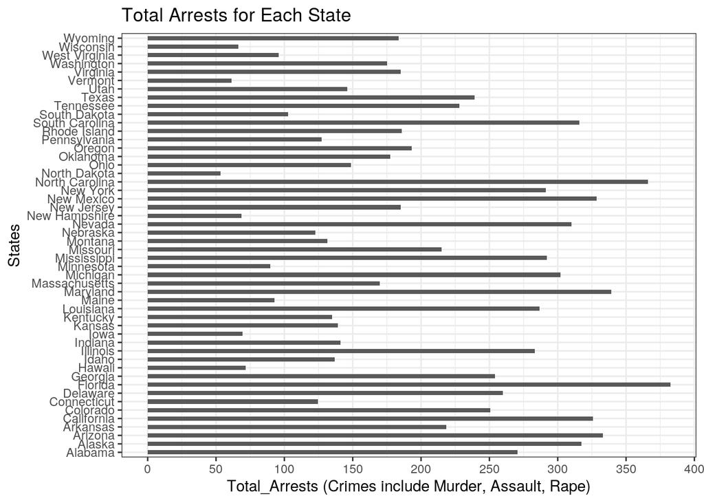

```r
ggplot(data3, aes(x = Total_Arrests)) + geom_bar(aes(y = States),
    stat = "summary", width = 0.5) + scale_x_continuous(breaks = seq(0,
    400, 50)) + theme_bw() + xlab("Total_Arrests (Crimes include Murder, Assault, Rape)") +
    ggtitle("Total Arrests for Each State")
```

```r
# ggplot(data3, aes(x = high_low_UrbanPercent, fill=States))+
# geom_bar(position='fill') + scale_fill_brewer()
```

This plot shows a bar graph for each of the 50 states of the total arrests. The plot depicts Florida with the highest number of criminal arrests. This finding is a little humorous to me because today on social media I often come across news articles of weird crimes that were committed in Florida.

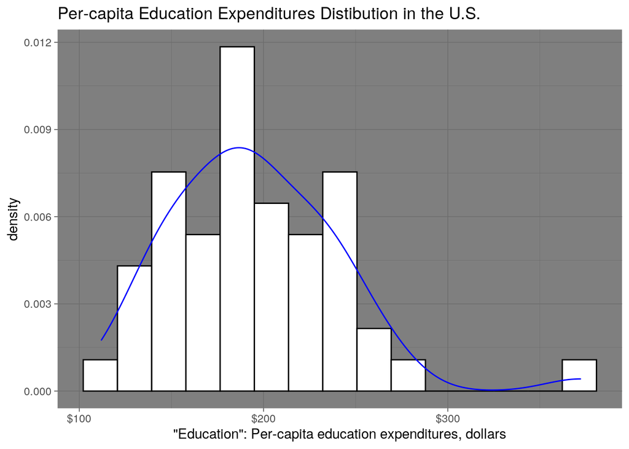

```r
ggplot(data3, aes(x = education)) + geom_histogram(aes(y = ..density..),
    color = "black", fill = "white", bins = 15) + geom_density(color = "blue") +
    scale_x_continuous(labels = scales::dollar) + xlab("\"Education\": Per-capita education expenditures, dollars") +
    ggtitle("Per-capita Education Expenditures Distibution in the U.S.") +
    theme_dark()
```

This plot is a histogram of the per-capita education expenditures in the U.S. The plot depicts that average amount of per-capita education expenditures is around $200 in the country.